# Texture Recognition Analysis

Andres Gomez Emilsson

March 19, 2015

This is the analysis for the replication of Balas (2006) on texture discrimination. Participants were presented with three images, one of which was different from the other two and asked to select the “odd one out.”

## The data set

The data contains 60 subjects, each performing a total of actions: In addition to 60 ‘real trials’ that measure what we care about, we also have 4 ‘example trials’ where the odd one out is known to the participant and 6 ‘sanity checks’ (4 extremelly easy ones, 2 difficult) to determine whether participants were paying attention and understood the instructions (know which keys to press).

```r
#install.packages('dplyr', repos='http://cran.rstudio.com/')
#install.packages('tidyr', repos='http://cran.rstudio.com/')
library(dplyr)
```

```r
library(tidyr)
#install.packages('ggplot2')
library(ggplot2)
#install.packages('binom')
library(binom)

library(lme4)
```

## Part 1: Data cleaning

```r
setwd("~/Documents/Stanford/Winter2015/Psych254/hello/texture_data")
d <- read.csv("real_trial.tsv", header=TRUE, sep="\t", row.names=NULL, stringsAsFactors = FALSE)
```

We now transform the values in arrays used to serialize the responses into individual variables (one column for each array index). Note this is done on for Answer.correct_ordered_trials and Answer.responses

```r
d <- subset(d, select = c(workerid, Answer.responses, Answer.correct_ordered_trials, Answer.example_chosen_positions, Answer.total_top, Answer.total_left, Answer.total_right, Answer.total_correct, Answer.about, Answer.comment, Answer.age, Answer.gender, Answer.time_shown))


nam <- names(d)
correct <- d$Answer.total_correct

# De-serialize the arrays
df <- NULL
for (i in 1:length(d$Answer.responses)) {
  is_responses <- d$Answer.responses[i]
  is_responses <- substr(is_responses, 2, 132)
  values <- as.integer(strsplit(is_responses, ",")[[1]])

  is_by_trial <- d$Answer.correct_ordered_trials[i]
  is_by_trial <- substr(is_by_trial, 2, 132)
  values_by_trial <- as.integer(strsplit(is_by_trial, ",")[[1]])
  new_row_values <- c(values, values_by_trial)

  example_response <- d$Answer.example_chosen_positions[i]
  example_response <- substr(example_response, 2, 8)
  value_of_examples <- as.integer(strsplit(example_response, ",")[[1]])
  new_row_values <- c(new_row_values, value_of_examples)

  df <- rbind(df, new_row_values)
}

# Responses (absolute stimuli names) and responses by trials. This constructs a vector with the names for the de-serialized variables.
vector_names <- c()
for (i in 1:12) {
  cn <- paste("full_set_", as.character(i), sep = "")
  vector_names <- c(vector_names, cn)
}
for (i in 1:12) {
  cn <- paste("local_phase_", as.character(i), sep = "")
  vector_names <- c(vector_names, cn)
}
for (i in 1:12) {
  cn <- paste("magnitude_corr_", as.character(i), sep = "")
  vector_names <- c(vector_names, cn)
}
for (i in 1:12) {
  cn <- paste("marginals_", as.character(i), sep = "")
  vector_names <- c(vector_names, cn)
}
for (i in 1:12) {
  cn <- paste("subband_corr_", as.character(i), sep = "")
  vector_names <- c(vector_names, cn)
}
vector_names <- c(vector_names, "calibration_60_190", "calibration_190_60", "calibration_10_240", "calibration_240_10", "calibration_110_130", "calibration_130_110")

for (i in 1:66) {
  cn <- paste("correct_by_trial_", as.character(i), sep = "")
  vector_names <- c(vector_names, cn)
}

for (i in 1:4) {
  cn <- paste("example_trial_", as.character(i), sep = "")
  vector_names <- c(vector_names, cn)
}

colnames(df) <- vector_names
rownames(df) <- 1:60
df <- as.data.frame(df)

df$number_of_examples_correct <- (df$example_trial_1 == 0) + (df$example_trial_2 == 2) + (df$example_trial_3 == 2) + (df$example_trial_4 == 1)

# Remove further variables that occupy a lot of space and are not needed anymore: The arrays
d <- subset(d, select =c(workerid, Answer.total_top, Answer.total_left, Answer.total_right, Answer.total_correct, Answer.about, Answer.comment, Answer.age, Answer.gender, Answer.time_shown))


# This binds the de-serialized variables to a main wide style frame
wide_d <- cbind(d, df)
```

```
## geom_smooth: method="auto" and size of largest group is <1000, so using loess. Use 'method = x' to change the smoothing method.
```

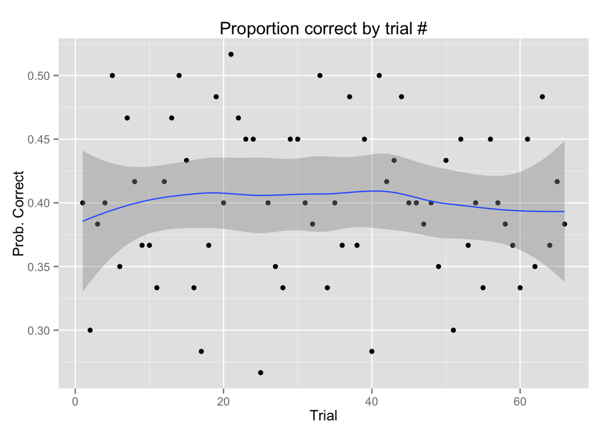

```r
# By trial
by_t <- qplot(x = 1:66, colMeans(wide_d[,77:142]))
by_t + stat_smooth() + xlab("Trial") + ylab("Prob. Correct") +  ggtitle("Proportion correct by trial #")
```

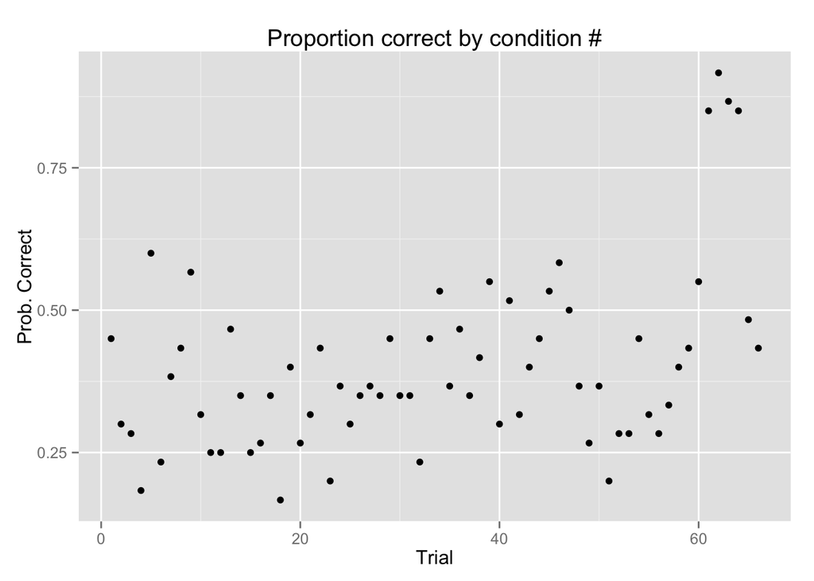

```r
# By ordered conditions
by_c <- qplot(x = 1:66, colMeans(wide_d[,11:76]))
by_c + xlab("Trial") + ylab("Prob. Correct") +  ggtitle("Proportion correct by condition #")
```

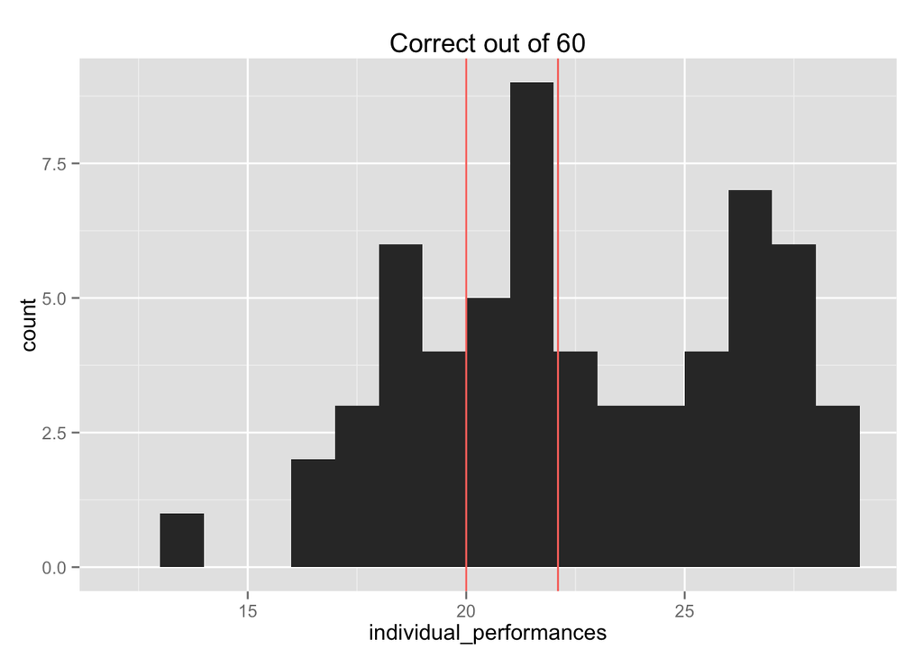

```r
# Plot of individual performances
individual_performances <- rowSums(wide_d[,11:70])
wide_d$individual_performances <- individual_performances
individual_performances <- data.frame(individual_performances)
mm <- mean(individual_performances$individual_performances)
qplot(individual_performances, data=individual_performances, geom="histogram", binwidth = 1) +  geom_vline(aes(xintercept=c(20, mm), color = "0000ff")) + ggtitle("Correct out of 60")
```

```r
# Test for normalcy. It does not seem normal... maybe there are two underlying strategies used.
shapiro.test(individual_performances$individual_performances)
```

```
##
##  Shapiro-Wilk normality test
##
## data:  individual_performances$individual_performances
## W = 0.955, p-value = 0.02684
```

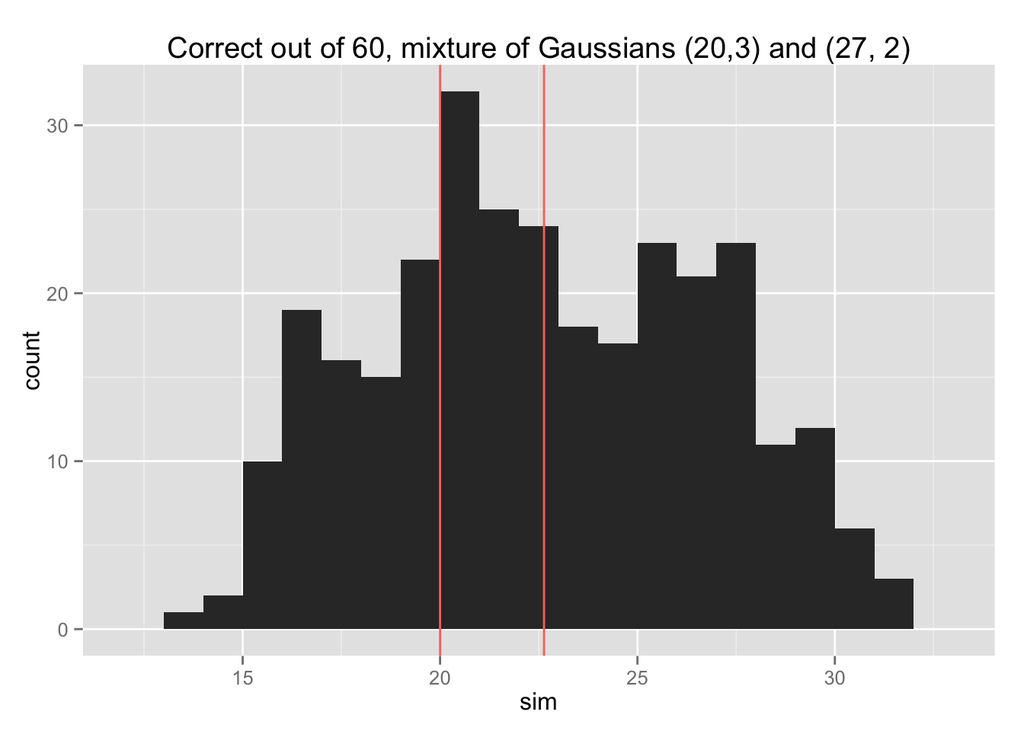

```r
# As a comparison, here is a simulation (with five times as many samples for smoothness) where the histogram is created by sampling from two Gaussain distribtiions with different means and standard deviations to approximate the empirical results.
sim <- c(rnorm(200, 20, 3), rnorm(100, 27, 2))
msim <- mean(sim)
qplot(sim, geom="histogram", binwidth = 1) +  geom_vline(aes(xintercept=c(20, msim), color = "0000ff")) + ggtitle("Correct out of 60, mixture of Gaussians (20,3) and (27, 2)")
```

```r
# And testing the normality of the simulated data.
shapiro.test(sim)
```

```
##
##  Shapiro-Wilk normality test
##
## data:  sim
## W = 0.979, p-value = 0.0002164
```

## Part 3: Turning into tidy data

The gather operation to get a d.tidy tidy frame with one raw per each trial that we care about.

```r
d.tidy <- wide_d %>% gather("trial", "answer", 11:76)

# Add features to each of the trials.
#Here is statistic removed
condition_labs <- rep("full_set", 12*60)
condition_labs <- c(condition_labs, rep("local_phase", 12*60))
condition_labs <- c(condition_labs,  rep("magnitude_corr", 12*60))
condition_labs <- c(condition_labs, rep("marginals", 12*60))
condition_labs <- c(condition_labs, rep("subband_corr", 12*60))
condition_labs <- c(condition_labs, rep("calibration_easy", 4*60))
condition_labs <- c(condition_labs, rep("calibration_hard", 2*60))
d.tidy$condition_labs <- condition_labs

# Here is the specific image used
image_kind <- rep("branches", 2*60)
image_kind <- c(image_kind, rep("ice", 2*60))
image_kind <- c(image_kind, rep("black_ovals", 2*60))
image_kind <- c(image_kind, rep("wall_ovals", 2*60))
image_kind <- c(image_kind, rep("mosaic", 2*60))
image_kind <- c(image_kind, rep("wall_rocks", 2*60))
image_kind <- rep(image_kind, 5)
image_kind <- c(image_kind, rep("calibration_easy", 4*60), rep("calibration_hard", 2*60))
d.tidy$image_kind <- image_kind

# Here show whether the odd_one is the synthetic or the original one
odd_one_kind <- rep(c("original", "synthetic"), 60*12*5/2)
odd_one_kind <- c(odd_one_kind, rep("calibration_easy", 4*60), rep("calibration_hard", 2*60))
d.tidy$odd_one_kind <- odd_one_kind
```

## Part 4: Plotting results

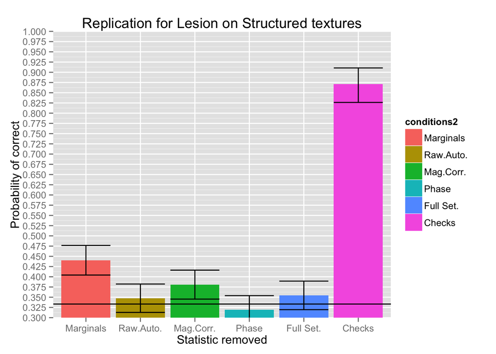

```r
answers_by_condition <- aggregate(cbind(answer) ~
                             condition_labs, data=d.tidy, sum)

accuracies <- answers_by_condition$answer
marginals <- accuracies[6]
subband_corrs <- accuracies[7]
magnitude_corrs <- accuracies[5]
local_phases <- accuracies[4]
full_sets <- accuracies[3]
calibrations <- accuracies[1]


total_per_condition <- length(wide_d[,1])*12
of_possible = c(total_per_condition, total_per_condition, total_per_condition, total_per_condition, total_per_condition, length(wide_d[,1])*4)
conditions <- c("Marginals", "Raw.Auto.", "Mag.Corr.", "Phase", "Full Set.", "Checks")
corrects =  c(marginals, subband_corrs, magnitude_corrs, local_phases, full_sets, calibrations)
correct_per_condition <- data.frame(conditions = conditions, corrects = corrects,
                                    of_possible = of_possible)


correct_per_condition$means <- correct_per_condition$corrects / correct_per_condition$of_possible

# To order properly
correct_per_condition$conditions2 <- factor(correct_per_condition$conditions, as.character(correct_per_condition$conditions))


# Use ggplot to show the results.
means.barplot <- ggplot(aes(x = conditions2, y=means, fill = conditions2),
                       data=correct_per_condition,  stat="identity") + coord_cartesian(ylim = c(0.3, 1)) + ggtitle("Replication for Lesion on Structured textures")
means.barplot + geom_bar(stat = "identity", position = "stack") + geom_errorbar(aes(ymax=binom.confint(corrects, of_possible, conf.level = 0.95, methods = "bayes")$upper,
                                  ymin=binom.confint(corrects, of_possible, conf.level = 0.95, methods = "bayes")$lower),
                              position=position_dodge(0.9),
                              data=correct_per_condition) + scale_y_continuous(breaks = seq(0.3,1, by = 0.025)) +
  xlab("Statistic removed") + ylab("Probability of correct") +  geom_hline(aes(yintercept=c(0.333333)))
```

```r
# The mean accuracy for each of the images (aggregated accros statistic removed condition).
answers_by_image_kind <- aggregate(cbind(answer) ~
                             image_kind, data=d.tidy, mean)
answers_by_image_kind
```

```
##         image_kind    answer
## 1      black_ovals 0.3716667
## 2         branches 0.3616667
## 3 calibration_easy 0.8708333
## 4 calibration_hard 0.4583333
## 5              ice 0.3033333
## 6           mosaic 0.4466667
## 7       wall_ovals 0.3516667
## 8       wall_rocks 0.3750000
```

```r
# The mean accuracy depending on whether the synthetic or the original was the odd one out.
answers_by_odd_one_kind <- aggregate(cbind(answer) ~
                             odd_one_kind, data=d.tidy, mean)
answers_by_odd_one_kind
```

```
##       odd_one_kind    answer
## 1 calibration_easy 0.8708333
## 2 calibration_hard 0.4583333
## 3         original 0.3555556
## 4        synthetic 0.3811111
```

```r
# The mean accuracy partitioned by specific image and condition.
answer_comb <- answers_by_odd_one_kind <- aggregate(cbind(answer) ~
                             condition_labs + image_kind, data=d.tidy, mean)
answer_comb
```

```
##      condition_labs       image_kind    answer
## 1          full_set      black_ovals 0.4166667
## 2       local_phase      black_ovals 0.2583333
## 3    magnitude_corr      black_ovals 0.4000000
## 4         marginals      black_ovals 0.4166667
## 5      subband_corr      black_ovals 0.3666667
## 6          full_set         branches 0.3750000
## 7       local_phase         branches 0.4083333
## 8    magnitude_corr         branches 0.3250000
## 9         marginals         branches 0.3833333
## 10     subband_corr         branches 0.3166667
## 11 calibration_easy calibration_easy 0.8708333
## 12 calibration_hard calibration_hard 0.4583333
## 13         full_set              ice 0.2333333
## 14      local_phase              ice 0.2583333
```

[output cut: 18 more lines]

## Part 5: Analysis

```r
# Difference from chance for each condition
prop.test(marginals, total_per_condition, p = 0.33333)
```

```
##
##  1-sample proportions test with continuity correction
##
## data:  marginals out of total_per_condition, null probability 0.33333
## X-squared = 36.579, df = 1, p-value = 1.466e-09
## alternative hypothesis: true p is not equal to 0.33333
## 95 percent confidence interval:
##  0.4037447 0.4774569
## sample estimates:
##         p
## 0.4402778
```

```r
prop.test(subband_corrs, total_per_condition, p = 0.33333)
```

```
##
##  1-sample proportions test with continuity correction
##
## data:  subband_corrs out of total_per_condition, null probability 0.33333
## X-squared = 0.5644, df = 1, p-value = 0.4525
## alternative hypothesis: true p is not equal to 0.33333
## 95 percent confidence interval:
##  0.3126663 0.3834321
## sample estimates:
##         p
## 0.3472222
```

```r
prop.test(local_phases, total_per_condition, p = 0.33333)
```

```
##
##  1-sample proportions test with continuity correction
##
## data:  local_phases out of total_per_condition, null probability 0.33333
## X-squared = 0.5638, df = 1, p-value = 0.4527
## alternative hypothesis: true p is not equal to 0.33333
## 95 percent confidence interval:
##  0.2857510 0.3550933
## sample estimates:
##         p
## 0.3194444
```

```r
prop.test(magnitude_corrs, total_per_condition, p = 0.33333)
```

```
##
##  1-sample proportions test with continuity correction
##
## data:  magnitude_corrs out of total_per_condition, null probability 0.33333
## X-squared = 7.0151, df = 1, p-value = 0.008083
## alternative hypothesis: true p is not equal to 0.33333
## 95 percent confidence interval:
##  0.3451353 0.4172684
## sample estimates:
##         p
## 0.3805556
```

```r
prop.test(full_sets, total_per_condition, p = 0.33333)
```

```
##
##  1-sample proportions test with continuity correction
##
## data:  full_sets out of total_per_condition, null probability 0.33333
## X-squared = 1.3145, df = 1, p-value = 0.2516
## alternative hypothesis: true p is not equal to 0.33333
## 95 percent confidence interval:
##  0.3194157 0.3904963
## sample estimates:
##         p
## 0.3541667
```

```r
# Determining the order of accuracy improvements
prop.test(c(marginals, magnitude_corrs), c(total_per_condition, total_per_condition), alternative = c("greater"))
```

```
##
##  2-sample test for equality of proportions with continuity
##  correction
##
## data:  c(marginals, magnitude_corrs) out of c(total_per_condition, total_per_condition)
## X-squared = 5.0625, df = 1, p-value = 0.01222
## alternative hypothesis: greater
## 95 percent confidence interval:
##  0.01576767 1.00000000
## sample estimates:
##    prop 1    prop 2
## 0.4402778 0.3805556
```

```r
# Difference between the accuracy for each condition where a statistical constraint is removed compared to the full set condtion:
prop.test(c(marginals, full_sets), c(total_per_condition, total_per_condition), alternative = c("greater"))
```

```
##
##  2-sample test for equality of proportions with continuity
##  correction
##
## data:  c(marginals, full_sets) out of c(total_per_condition, total_per_condition)
## X-squared = 10.7921, df = 1, p-value = 0.0005097
## alternative hypothesis: greater
## 95 percent confidence interval:
##  0.04246668 1.00000000
## sample estimates:
##    prop 1    prop 2
## 0.4402778 0.3541667
```

```r
prop.test(c(subband_corrs, full_sets), c(total_per_condition, total_per_condition), alternative = c("greater"))
```

```
##
##  2-sample test for equality of proportions with continuity
##  correction
##
## data:  c(subband_corrs, full_sets) out of c(total_per_condition, total_per_condition)
## X-squared = 0.0488, df = 1, p-value = 0.5874
## alternative hypothesis: greater
## 95 percent confidence interval:
##  -0.04970028  1.00000000
## sample estimates:
##    prop 1    prop 2
## 0.3472222 0.3541667
```

```r
prop.test(c(local_phases, full_sets), c(total_per_condition, total_per_condition), alternative = c("greater"))
```

```
##
##  2-sample test for equality of proportions with continuity
##  correction
##
## data:  c(local_phases, full_sets) out of c(total_per_condition, total_per_condition)
## X-squared = 1.7908, df = 1, p-value = 0.9096
## alternative hypothesis: greater
## 95 percent confidence interval:
##  -0.07705536  1.00000000
## sample estimates:
##    prop 1    prop 2
## 0.3194444 0.3541667
```

```r
prop.test(c(magnitude_corrs, full_sets), c(total_per_condition, total_per_condition), alternative = c("greater"))
```

```
##
##  2-sample test for equality of proportions with continuity
##  correction
##
## data:  c(magnitude_corrs, full_sets) out of c(total_per_condition, total_per_condition)
## X-squared = 0.9681, df = 1, p-value = 0.1626
## alternative hypothesis: greater
## 95 percent confidence interval:
##  -0.01677705  1.00000000
## sample estimates:
##    prop 1    prop 2
## 0.3805556 0.3541667
```

```r
# Additional analysis - with possible random and fixed effects, such as the particular particupant.

fixed_by_user <- lmer(answer ~ condition_labs + (1 | workerid), data = d.tidy)
summary(fixed_by_user)
```

```
## Linear mixed model fit by REML ['lmerMod']
## Formula: answer ~ condition_labs + (1 | workerid)
##    Data: d.tidy
##
## REML criterion at convergence: 5359.2
##
## Scaled residuals:
##     Min      1Q  Median      3Q     Max
## -1.8668 -0.7705 -0.6922  1.2762  1.4897
##
## Random effects:
##  Groups   Name        Variance  Std.Dev.
##  workerid (Intercept) 0.0006237 0.02497
##  Residual             0.2241154 0.47341
## Number of obs: 3960, groups:  workerid, 60
##
## Fixed effects:
##                                Estimate Std. Error t value
## (Intercept)                     0.87083    0.03073  28.340
## condition_labscalibration_hard -0.41250    0.05293  -7.794
## condition_labsfull_set         -0.51667    0.03529 -14.642
## condition_labslocal_phase      -0.55139    0.03529 -15.626
## condition_labsmagnitude_corr   -0.49028    0.03529 -13.894
## condition_labsmarginals        -0.43056    0.03529 -12.202
## condition_labssubband_corr     -0.52361    0.03529 -14.839
##
## Correlation of Fixed Effects:
##             (Intr) cndtn_lbsc_ cndtn_lbsf_ cndtn_lbsl_ cndtn_lbsm_ cndtn_
## cndtn_lbsc_ -0.574
## cndtn_lbsf_ -0.861  0.500
## cndtn_lbsl_ -0.861  0.500       0.750
## cndtn_lbsm_ -0.861  0.500       0.750       0.750
## cndtn_lbsmr -0.861  0.500       0.750       0.750       0.750
## cndtn_lbss_ -0.861  0.500       0.750       0.750       0.750       0.750
```

Here we have a few miscelaneous analysis and exploration that seek to gain insights into the problems with the replication.

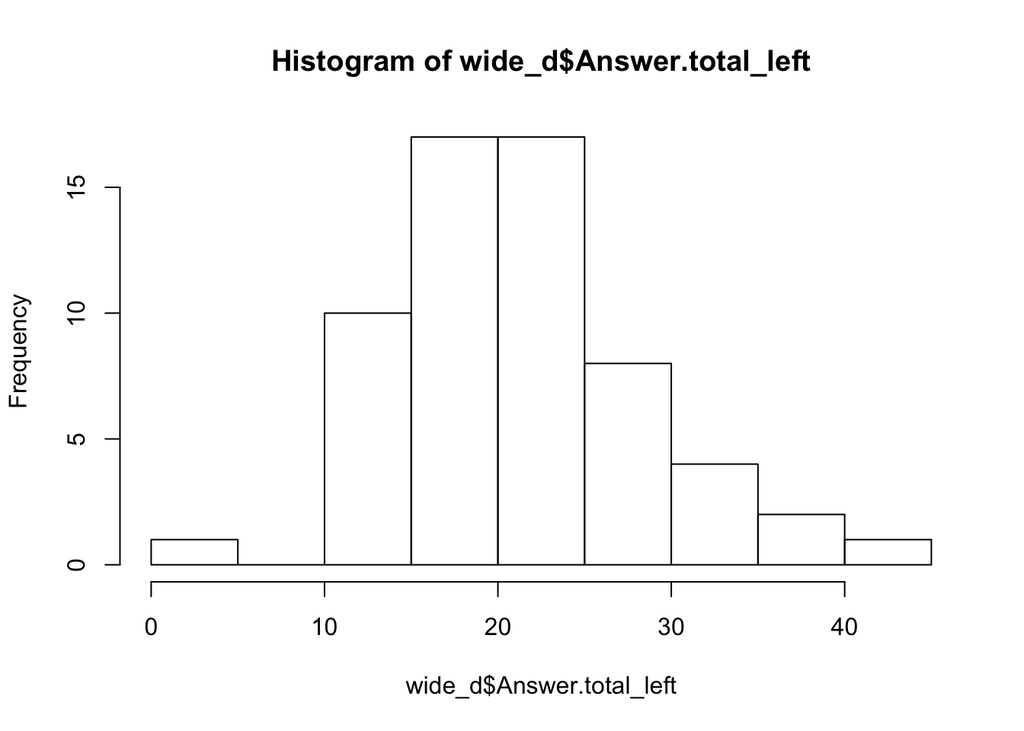

```r
hist(wide_d$Answer.total_left)
```

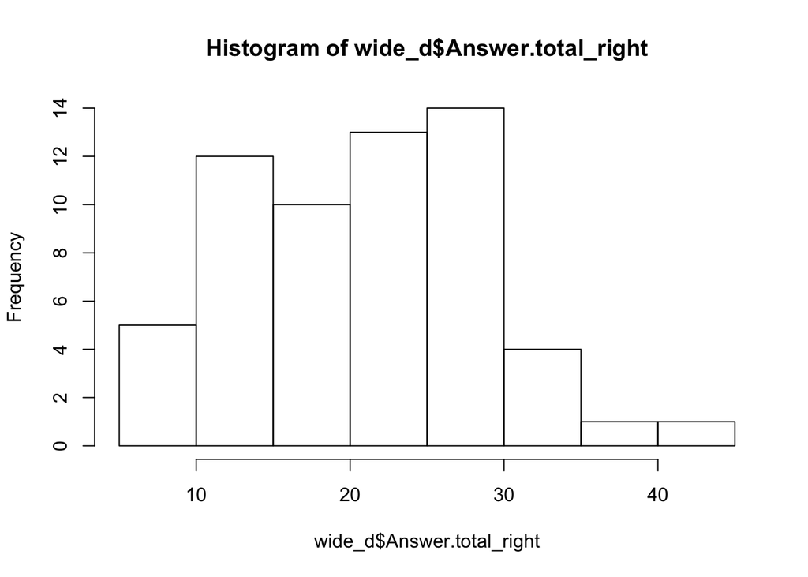

```r
hist(wide_d$Answer.total_right)
```

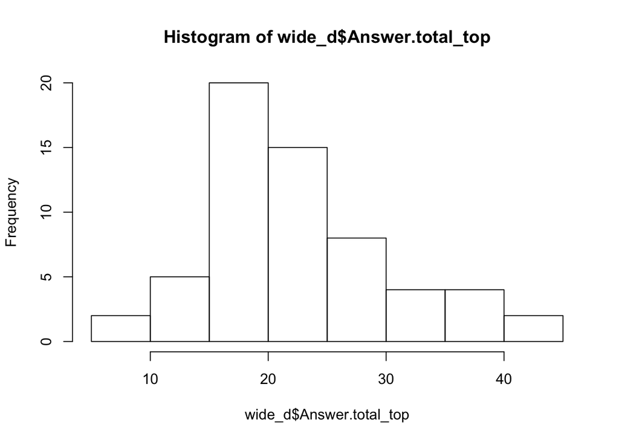

```r
hist(wide_d$Answer.total_top)
```

```r
wide_d$Answer.comment
```

```
##  [1] "\"that was hard!\""
##  [2] "\"\""
##  [3] "\"Thanks\""
##  [4] "\"\""
##  [5] "\"This... this was a hard survey.\""
##  [6] "\"\""
##  [7] "\"NO\""
##  [8] "\"This was difficult.\""
##  [9] "\"\""
## [10] "\"it was interesting, thank you\""
## [11] "\"\""
## [12] "\"\""
## [13] "\"\""
## [14] "\"I'm not sure I was any good at this, but I did try\""
## [15] "\"VERY challenging!!!\""
```

[output cut: 45 more lines]

```r
d.tidy$male <-
  d.tidy$Answer.gender == "\"m\"" |
  d.tidy$Answer.gender == "\"M\"" |
  d.tidy$Answer.gender == "\"male\"" |
  d.tidy$Answer.gender == "\"Male\""

summary(glm(answer ~ male + condition_labs, data = d.tidy))
```

```
##
## Call:
## glm(formula = answer ~ male + condition_labs, data = d.tidy)
##
## Deviance Residuals:
##     Min       1Q   Median       3Q      Max
## -0.8741  -0.3574  -0.3227   0.6162   0.6834
##
## Coefficients:
##                                 Estimate Std. Error t value Pr(>|t|)
## (Intercept)                     0.874080   0.031646  27.621  < 2e-16 ***
## maleTRUE                       -0.006088   0.015102  -0.403    0.687
## condition_labscalibration_hard -0.412500   0.053007  -7.782 9.05e-15 ***
## condition_labsfull_set         -0.516667   0.035338 -14.621  < 2e-16 ***
## condition_labslocal_phase      -0.551389   0.035338 -15.603  < 2e-16 ***
## condition_labsmagnitude_corr   -0.490278   0.035338 -13.874  < 2e-16 ***
## condition_labsmarginals        -0.430556   0.035338 -12.184  < 2e-16 ***
## condition_labssubband_corr     -0.523611   0.035338 -14.817  < 2e-16 ***
## ---
## Signif. codes:  0 '***' 0.001 '**' 0.01 '*' 0.05 '.' 0.1 ' ' 1
##
## (Dispersion parameter for gaussian family taken to be 0.2247774)
##
##     Null deviance: 951.59  on 3959  degrees of freedom
## Residual deviance: 888.32  on 3952  degrees of freedom
## AIC: 5337.1
##
## Number of Fisher Scoring iterations: 2
```

```r
# People who said that the experiment was hard (that exact word)
hard <- c(1, 5, 33, 34, 60)

# People who said it was challenging in some way or another.
challenging <- c(1, 5, 8, 14, 15, 26, 30, 33, 34, 35, 42, 43, 44, 51, 60)

wide_d$said_it_was_challenging <- 1:60 %in% challenging

score_given_hard <- subset(wide_d$Answer.total_correct, wide_d$said_it_was_challenging)
score_given_lack_of_hard_comment <- subset(wide_d$Answer.total_correct, !wide_d$said_it_was_challenging)
mean(score_given_hard)
```

```
## [1] 28
```

```r
mean(score_given_lack_of_hard_comment)
```

```
## [1] 26
```

```r
# To test whether the scores of people who mentioned that it was hard are not
# significantly different from those who didn't.
t.test(score_given_hard, score_given_lack_of_hard_comment)
```

```
##
##  Welch Two Sample t-test
##
## data:  score_given_hard and score_given_lack_of_hard_comment
## t = 1.4831, df = 20.891, p-value = 0.153
## alternative hypothesis: true difference in means is not equal to 0
## 95 percent confidence interval:
##  -0.8053786  4.8053786
## sample estimates:
## mean of x mean of y
##        28        26
```